# linearalgebra_practice113114115

```python
%%html
<style>
@import url('https://fonts.googleapis.com/css?family=Roboto&effect=3d|brick-sign|');
span {font-family:Roboto; color:black; text-shadow:4px 4px 4px #aaa;}
h1,h2 {font-family:Roboto; color:slategray; text-shadow:4px 4px 4px #aaa;}
div.output_subarea, div.output_area pre{font-family:Roboto; font_size:120%; color:darkblue;}
</style>
```

```python
import math, sympy, numpy
sympy.init_printing(use_unicode=True)
from sympy import *
from mpmath import *
from sympy.physics.vector import *

from mpl_toolkits.mplot3d import Axes3D
from mpl_toolkits.mplot3d.art3d import Poly3DCollection, Line3DCollection

import warnings
warnings.simplefilter("ignore", category=RuntimeWarning)

import pylab as plt
import matplotlib
%matplotlib inline
```

[Computer Algebra I: Mathematica, SymPy, Sage, Maxima](http://hyperpolyglot.org/computer-algebra2)

[SymPy. Vector & ReferenceFrame](https://docs.sympy.org/latest/modules/physics/vector/vectors.html)

LaTeX/Mathematics

[МЦНМО. Свободно распространяемые издания](https://www.mccme.ru/free-books/)

# Типовой расчет 13 / Standard Calculation 13

## Постановка задачи / Formulation of the problem:

По координатам вершин треугольника $ABC$ найти

канонические уравения высоты, опущенной из вершины $A$.

$A (9; -2; -6); B (14; 11; -12); C (17; -4; 0)$

## Решение / Decision

1) Запишем канонические уравнения прямой $BC$,

проходящей через вершины треугольника $B$ и $C$:

$\large{\frac{X - X_B}{X_C - X_B} = \frac{Y - Y_B}{Y_C - Y_B} = \frac{Z - Z_B}{Z_C - Z_B}}$

$\large{\frac{X - 14}{17 - 14} = \frac{Y - 11}{-4 - 11} = \frac{Z - (-12)}{0 - (-12)}}$

$\large{\frac{X - 14}{1} = \frac{Y - 11}{-5} = \frac{Z + 12}{4}}$.

или в параметрическом виде:

$BC: \begin{cases} X = T + 14 \\ Y = -5T + 11 \\ Z = 4T - 12 \end{cases} $

2) Найдем координаты точки $D$ - точки пересечения прямой $BC$

и перпендикулярной ей прямой, содержащей высоту $AD$ и проходящую через вершину $A$:

$D \in BC \implies \begin{cases} X_D = T_D + 14 \\ Y_D = -5T_D + 11 \\ Z_D = 4T_D - 12 \end{cases}$

$\overrightarrow{AD} \perp \overrightarrow{BC} \implies \overrightarrow{AD} \cdot \overrightarrow{BC} = 0$

Запишем координаты векторов $\overrightarrow{AD}$ и $\overrightarrow{BC}$:

$\overrightarrow{AD} \{T_D + 14 - 9; -5T_D + 11 + 2; 4T_D - 12 + 6\} = \{T_D + 5; -5T_D + 13; 4T_D - 6\}$

$\overrightarrow{BC} \{17 - 14; -4 - 11; 0 - (-12)\} = \{3; -15; 12\}$

$\overrightarrow{AD} \cdot \overrightarrow{BC} = 3 * (T_D + 5) - 15 * (-5T_D + 13) + 12 * (4T - 6) = 0$

$T_D + 5 + 25T_D - 65 + 16T_D - 24 = 0 \iff 42T_D = 84 \iff T_D = 2$

$\implies D (2 + 14; -5 * 2 + 11; 4 * 2 - 12) = (16; 1; -4)$

3) Запишем канонические уравнения прямой $AD$,

содержащей высоту $\triangle ABC$ и проходящей через точки $A$ и $D$:

$\large{\frac{X - X_A}{X_D - X_A} = \frac{Y - Y_A}{Y_D - Y_A} = \frac{Z - Z_A}{Z_D - Z_A}}$

$\large{\frac{X - 9}{16 - 9} = \frac{Y - (-2)}{1 - (-2)} = \frac{Z - (-6)}{-4 - (-6)}}$

$\large{\frac{X - 9}{7} = \frac{Y + 2}{3} = \frac{Z + 6}{2}}$.

```python
t = -0.7; X = numpy.linspace(8, 18, 50)
xA, yA, zA = 9,-2,-6
xB, yB, zB = 14,11,-12
xC, yC, zC = 17,-4,0

TD = sympy.symbols('TD')
BC = sympy.Matrix([xC-xB,yC-yB,zC-zB])/3
xD,yD,zD = BC[0]*TD+xB, BC[1]*TD+yB, BC[2]*TD+zB
AD = sympy.Matrix([xD-xA,yD-yA,zD-zA])
TD = sympy.solve(BC.dot(AD))[0]
xD,yD,zD = BC[0]*TD+xB, BC[1]*TD+yB, BC[2]*TD+zB

YBC = (yC-yB) /(xC-xB)* (X-xB) + yB
ZBC = (zC-zB) /(xC-xB)* (X-xB) + zB
YBC[YBC < -10] = numpy.NaN; YBC[YBC > 18] = numpy.NaN
ZBC[ZBC < -15] = numpy.NaN; ZBC[ZBC > 3] = numpy.NaN

YAD = (yD-yA) /(xD-xA)* (X-xA) + yA
ZAD = (zD-zA) /(xD-xA)* (X-xA) + zA
```

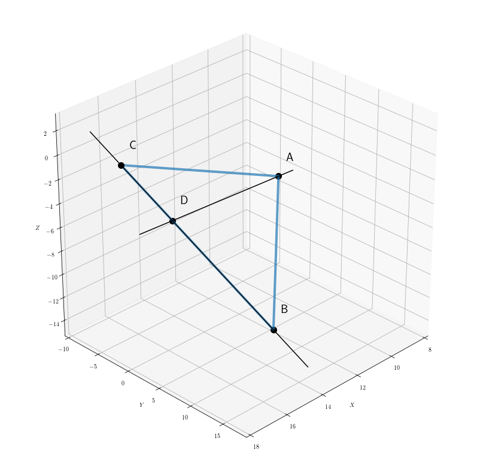

```python
f = plt.figure(figsize=(14,14)); ax = f.add_subplot(111, projection='3d')
matplotlib.rcParams['text.usetex'] = True; matplotlib.rcParams['text.latex.unicode'] = True

P = numpy.array([[xA, yA, zA,'A'], [xB, yB, zB,'B'], [xC, yC, zC,'C'],[16,1,-4,'D']])
ax.plot(P[[0,1,2,0],0].astype('int16'), P[[0,1,2,0],1].astype('int16'), P[[0,1,2,0],2].astype('int16'),
       lw=4, alpha=0.7)
for point in P:
    ax.scatter(int(point[0]), int(point[1]), int(point[2]), point[3], c='black', s=100)
    ax.text(int(point[0])+t, int(point[1])+t, int(point[2])-t, point[3], fontsize=20)
ax.plot(X, YBC,  ZBC, c='black'); ax.plot(X, YAD,  ZAD, c='black')

ax.set_xlim(8,18); ax.set_ylim(-10,18); ax.set_zlim(-15,3)
ax.set_xlabel(r'$X$'); ax.set_ylabel(r'$Y$'); ax.set_zlabel(r'$Z$');
ax.view_init(30,45);
```

# Типовой расчет 14 / Standard Calculation 14

## Постановка задачи / Formulation of the problem:

Через данную прямую $c$ проходят две плоскости.

Одна из них проходит через данную точку $A$, другая - через данную точку $B$.

Найти уравнения плоскостей, которые делят пополам двугранные углы,

образованные этими плоскостями.

$c: \frac{X + 1}{6} = \frac{Y - 1}{4} = \frac{Z}{9}; A (-5;-6;-9); B (2;5;11)$

```python
X,Y,Z,T = sympy.symbols('X,Y,Z,T')
eq_c1 = X-6*T+1
eq_c2 = Y-4*T-1
eq_c3 = Z-9*T
xA,yA,zA = -5,-6,-9; xB,yB,zB = 2,5,11
```

## Решение / Decision

1) Канонические уравнения прямой $c$ определяют кординаты направляющего вектора этой прямой: $\overrightarrow{c} \{6; 4; 9\}$.

Запишем уравнения прямой $c$ в параметрическом виде:

$с: \ \begin{cases} X = 6T - 1 \\ Y =4T + 1 \\ Z = 9T \end{cases}$

Выберем произвольные значения параметра $T_C=0, T_D=1$ и найдем координаты точек $C, D$, принадлежащих прямой $c$.

$C \ (6*0 - 1; 4*0 + 1; 9*0) = (-1; 1; 0), D \ (6*1 - 1; 4*1 + 1; 9*1) = (5; 5; 9)$

```python
# C, D
sC = sympy.solve([eq_c1,eq_c2,eq_c3,T])
sD = sympy.solve([eq_c1,eq_c2,eq_c3,T-1])
xC,yC,zC = sC[X],sC[Y],sC[Z]; xD,yD,zD = sD[X],sD[Y],sD[Z]
(xC,yC,zC), (xD,yD,zD)
```

$$\left ( \left ( -1, \quad 1, \quad 0\right ), \quad \left ( 5, \quad 5, \quad 9\right )\right )$$

2) Запишем уравнения плоскостей $\alpha, \beta$, проходящих через прямую $c$ с точками $C, D$ и точки $A, B$ соответственно.

$\alpha : \begin{vmatrix} X - X_A & Y - Y_A & Z - Z_A \\ X_C - X_A & Y_C - Y_A & Z_C - Z_A \\ X_D - X_A & Y_D - Y_A & Z_D - Z_A \\ \end{vmatrix} = 0, \ \beta : \begin{vmatrix} X - X_B & Y - Y_B & Z - Z_B \\ X_C - X_B & Y_C - Y_B & Z_C - Z_B \\ X_D - X_B & Y_D - Y_B & Z_D - Z_B \\ \end{vmatrix} = 0$

$\alpha : \begin{vmatrix} X + 5 & Y + 6 & Z + 9 \\ 4 & 7 & 9 \\ 10 & 11 & 18 \\ \end{vmatrix} = 0, \ \beta : \begin{vmatrix} X - 2 & Y - 5 & Z - 11 \\ -3 & -4 & -11 \\ 3 & 0 & -2 \\ \end{vmatrix} = 0$

$\alpha : (X + 5)(7*18-9*11) - (Y + 6)(4*18-9*10) + (Z + 9)(4*11-7*10) = 0, \\ \beta : (X - 2)(-4*(-2)-(-11)*0) - (Y - 5)(-3*(-2)-(-11)*3) + (Z - 11)(-3*0-(-4)*3) = 0$

$\alpha : 27X+18Y−26Z+9 = 0, \\ \beta : 8X−39Y+12Z+47 = 0$

```python
# 𝛼, 𝛽
eq_a = sympy.Matrix([[X-xA,Y-yA,Z-zA],[xC-xA,yC-yA,zC-zA],[xD-xA,yD-yA,zD-zA]]).det()
eq_b = sympy.Matrix([[X-xB,Y-yB,Z-zB],[xC-xB,yC-yB,zC-zB],[xD-xB,yD-yB,zD-zB]]).det()
eq_a, eq_b
```

$$\left ( 27 X + 18 Y - 26 Z + 9, \quad 8 X - 39 Y + 12 Z + 47\right )$$

```python
(X + 5)*(7*18-9*11) - (Y + 6)*(4*18-9*10) + (Z + 9)*(4*11-7*10), \
(X - 2)*(-4*(-2)-(-11)*0) - (Y - 5)*(-3*(-2)-(-11)*3) + (Z - 11)*(-3*0-(-4)*3)
```

$$\left ( 27 X + 18 Y - 26 Z + 9, \quad 8 X - 39 Y + 12 Z + 47\right )$$

3) Обозначим $\gamma_1, \gamma_2$ - плоскости, проходящие через прямую $c$ и делящие двугранные углы между $\alpha, \beta$ пополам.

Все точки, принадлежащие $\gamma_1, \gamma_2$ будут равноудалены от плоскостей $\alpha, \beta$,

а значит для них будет выполняться соотношение:

$\frac{|27X + 18Y - 26Z + 9|}{\sqrt{27^2 + 18^2 + (-26)^2}} = \frac{|8X - 39Y + 12Z + 47|}{\sqrt{8^2 + (-39)^2 + 12^2}}$

$\sqrt{27^2 + 18^2 + (-26)^2} = \sqrt{8^2 + (-39)^2 + 12^2} = \sqrt{1729} \implies$

$\gamma_1: 27X + 18Y - 26Z + 9 = 8X - 39Y + 12Z + 47, \\ \gamma_2: 27X + 18Y - 26Z + 9 = -(8X - 39Y + 12Z + 47)$

$\gamma_1: X + 3Y - 2Z - 2 = 0, \\ \gamma_2: 5X - 3Y - 2Z + 8 = 0$

```python
# 𝛾1,  𝛾2
g1 = sympy.sqrt(eq_a.coeff(X)**2+eq_a.coeff(Y)**2+eq_a.coeff(Z)**2)
g2 = sympy.sqrt(eq_b.coeff(X)**2+eq_b.coeff(Y)**2+eq_b.coeff(Z)**2)
eq_g1 = (eq_a - eq_b)/19; eq_g2 = (eq_a + eq_b)/7
g1, g2, eq_g1, eq_g2
```

$$\left ( \sqrt{1729}, \quad \sqrt{1729}, \quad X + 3 Y - 2 Z - 2, \quad 5 X - 3 Y - 2 Z + 8\right )$$

```python
# c
Xc = numpy.linspace(-14, 10, 50)
Yc = 2 * (Xc + 1) / 3 + 1; Zc = 3 * (Xc + 1) / 2

# 𝛼, 𝛽
X1 = numpy.linspace(-20, 20, 100)
Y1 = numpy.linspace(-20, 20, 100)
X1, Y1 = numpy.meshgrid(X1, Y1)
def alpha(x, y): return (27*x+18*y+9)/26
def beta(x, y): return (-8*x+39*y-47)/12
ZA = alpha(X1,Y1)
ZB = beta(X1,Y1)
X1[X1 < -12] = numpy.NaN; X1[X1 > 12] = numpy.NaN
Y1[Y1 < -12] = numpy.NaN; Y1[Y1 > 12] = numpy.NaN
ZA[ZA < -12] = numpy.NaN; ZA[ZA > 12] = numpy.NaN
ZB[ZB < -12] = numpy.NaN; ZB[ZB > 12] = numpy.NaN

# 𝛾1,  𝛾2
X2 = numpy.linspace(-20, 20, 100)
Y2 = numpy.linspace(-20, 20, 100)
X2, Y2 = numpy.meshgrid(X2, Y2)
def gamma1(x, y): return x/2+3*y/2-1
def gamma2(x, y): return 5*x/2-3*y/2+4
ZG1 = gamma1(X2,Y2)
ZG2 = gamma2(X2,Y2)
X2[X2 < -12] = numpy.NaN; X2[X2 > 12] = numpy.NaN
Y2[Y2 < -12] = numpy.NaN; Y2[Y2 > 12] = numpy.NaN
ZG1[ZG1 < -12] = numpy.NaN; ZG1[ZG1 > 12] = numpy.NaN
ZG2[ZG2 < -12] = numpy.NaN; ZG2[ZG2 > 12] = numpy.NaN
```

```python
# A,B,C,D
P = [[xA,yA,zA, r'$A$'], [xB,yB,zB,r'$B$'], [xC,yC,zC,r'$C$'],[xD,yD,zD,r'$D$']]
P = numpy.array(P); t=1
```

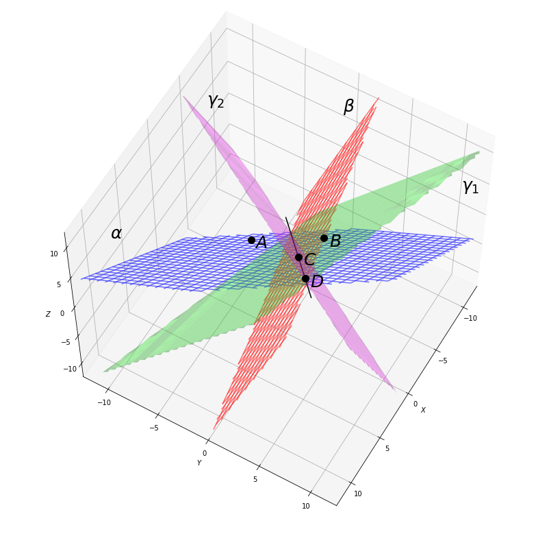

```python
f = plt.figure(figsize=(14,14)); ax = f.add_subplot(111, projection='3d')

ax.plot(Xc, Yc, Zc, c='black')
ax.plot_wireframe(X1,Y1,ZA,color='#3636ff',alpha=0.7); ax.text(10,-10,10,r'$\alpha$',fontsize=25)
ax.plot_wireframe(X1,Y1,ZB,color='#ff3636',alpha=0.7); ax.text(-10,0,10,r'$\beta$',fontsize=25)
ax.plot_surface(X2,Y2,ZG1,color='#36ff36',alpha=0.4); ax.text(-8,12,10,r'$\gamma_1$',fontsize=25)
ax.plot_surface(X2,Y2,ZG2,color='#ff36ff',alpha=0.4); ax.text(-5,-10,10,r'$\gamma_2$',fontsize=25)

for point in P:
    ax.scatter(int(point[0]), int(point[1]), int(point[2]), point[3], c='black', s=100)
    ax.text(int(point[0])+t, int(point[1])+t, int(point[2])+t, point[3], fontsize=25)

ax.set_xlim([-12,12]); ax.set_ylim([-12,12]); ax.set_zlim([-12,12])
ax.set_xlabel(r'$X$'); ax.set_ylabel(r'$Y$'); ax.set_zlabel(r'$Z$');
ax.view_init(60,30);
```

# Типовой расчет 15 / Standard Calculation 15

## Постановка задачи / Formulation of the problem:

Луч света идет вдоль прямой $L_1$, заданной как линия пересечения двух плоскостей,

и отражается от прямой $L_2$, также заданной как линия пересечения двух плоскостей.

Найти направляющий вектор прямой, вдоль которой пойдет отраженный луч.

Уравнения прямой $L_1: 2X - 29Y - Z + 135 = 0; X - 20Y - Z + 94 = 0$.

Уравнения прямой $L_2: 10X - 3Y - 5Z - 35 = 0; 5X - 9Y - 10Z + 5 = 0$.

## Решение / Decision

1) Найдем точку пересечения прямых $L_1$ и $L_2$. Обозначим ее $O$.

Ее координаты удовлетворяют системе четырех уравнений:

$\begin{cases} 2X - 29Y - Z + 135 = 0 (*)\\ X - 20Y - Z + 94 = 0 \\ 10X - 3Y - 5Z - 35 = 0 \\ 5X - 9Y - 10Z + 5 = 0 \end{cases}$

Из 1-ого уравнения вычтем 2-ое, из 4-ого вычтем 3-е, умноженное на 2:

$\begin{cases} X - 9Y + 41 = 0 (**) \\ -15X - 3Y + 75 = 0 \end{cases}$

Умножим на 3 2-е из полученных уравнений и вычтем из 1-ого:

$46X - 184 = 0 \iff X = 4 \implies $

$(**) \implies 4 - 9Y + 41 = 0 \implies Y = 5 \implies $

$(*) \implies 2 * 4 - 29 * 5 - Z + 135 = 0 \implies Z = -2$

$ L_1 \cap L_2 = O \ (4; 5; -2)$

```python
xO,yO,zO = sympy.symbols('xO,yO,zO')
system = sympy.Matrix([[2, -29, -1, -135], [1, -20, -1, -94], [10, -3, -5, 35], [5, -9, -10, -5]])
O = sympy.solve_linear_system(system, xO,yO,zO)
xO,yO,zO = O[xO],O[yO],O[zO]
O
```

$$\left \{ xO : 4, \quad yO : 5, \quad zO : -2\right \}$$

2) Запишем уравнения прямых $L_1$ и $L_2$ в каноническом и параметрическом виде.

Обе прямые заданы уравнениями плоскостей в общем виде.

Обозначим их направляющие векторы $\overrightarrow{l_{1}}, \ \overrightarrow{l_{2}}$ соответственно.

В случае $L_1$ вектора нормалей к плоскостям будут иметь координаты

$\overrightarrow{l_{11}} \{2; -29;-1\}$ и $\overrightarrow{l_{12}} \{1; -20; -1\}$.

$\overrightarrow{l_{1}} \perp \overrightarrow{l_{11}}, \ \overrightarrow{l_{1}} \perp \overrightarrow{l_{12}} \implies \overrightarrow{l_{1}} = \big[ \overrightarrow{l_{11}} \times \overrightarrow{l_{12}}\big] $

$ \overrightarrow{l_{1}} = \begin{vmatrix} \overrightarrow{i} & \overrightarrow{j} & \overrightarrow{k} \\ 2 & -29 & -1 \\ 1 & -20 & -1 \end{vmatrix} = \overrightarrow{i} \begin{vmatrix} -29 & -1 \\ -20 & -1 \end{vmatrix} - \overrightarrow{j} \begin{vmatrix} 2 & -1 \\ 1 & -1 \end{vmatrix} + \overrightarrow{k} \begin{vmatrix} 2 & -29 \\ 1 & -20 \end{vmatrix} = 9 \overrightarrow{i} + \overrightarrow{j} - 11 \overrightarrow{k}$

В случае $L_2$ вектора нормалей к плоскостям будут иметь координаты

$\overrightarrow{l_{21}} \{10; -3; -5\}$ и $\overrightarrow{l_{22}} \{5; -9; -10\}$.

$\overrightarrow{l_{2}} \perp \overrightarrow{l_{21}}, \ \overrightarrow{l_{2}} \perp \overrightarrow{l_{22}} \implies \overrightarrow{l_{2}} = \big[ \overrightarrow{l_{21}} \times \overrightarrow{l_{22}}\big] $

$ \overrightarrow{l_{2}} = \begin{vmatrix} \overrightarrow{i} & \overrightarrow{j} & \overrightarrow{k} \\ 10 & -3 & -5 \\ 5 & -9 & -10 \end{vmatrix} = \overrightarrow{i} \begin{vmatrix} -3 & -5 \\ -9 & -10 \end{vmatrix} - \overrightarrow{j} \begin{vmatrix} 10 & -5 \\ 5 & -10 \end{vmatrix} + \overrightarrow{k} \begin{vmatrix} 10 & -3 \\ 5 & -9 \end{vmatrix} = -15 \overrightarrow{i} + 75 \overrightarrow{j} - 75 \overrightarrow{k}$

$\overrightarrow{l_{2}}$ можно заменить параллельным вектром $\overrightarrow{l_{2}} = - \overrightarrow{i} + 5 \overrightarrow{j} - 5 \overrightarrow{k}$

По точке $O$ и направляющим векторам $\overrightarrow{l_{1}}, \overrightarrow{l_{2}}$ составим канонические уравнения прямых $L_1$ и $L_2$ .

$L_1: \frac {X - 4}{9} = \frac {Y - 5}{1} = \frac {Z + 2}{-11}$

$L_2: \frac {X - 4}{-1} = \frac {Y - 5}{5} = \frac {Z + 2}{-5}$

В параметрическом виде:

$L_1: \ \begin{cases} X = 9T + 4 \\ Y = T + 5 \\ Z = -11T - 2 \end{cases}$

$L_2: \ \begin{cases} X = -T + 4 \\ Y = 5T + 5 \\ Z = -5T - 2 \end{cases}$

```python
l11 = sympy.Matrix([2,-29,-1]) ; l12 = sympy.Matrix([1,-20,-1])
l21 = sympy.Matrix([10,-3,-5]) ; l22 = sympy.Matrix([5,-9,-10])
l1 = l11.cross(l12); l2 = l21.cross(l22)/15
l1, l2
```

$$\left ( \left[\begin{matrix}9\\1\\-11\end{matrix}\right], \quad \left[\begin{matrix}-1\\5\\-5\end{matrix}\right]\right )$$

```python
x,y,z,t = sympy.symbols('x,y,z,t')
eq11 = l1[0]*t+xO-x; eq12 = l1[1]*t+yO-y; eq13 = l1[2]*t+zO-z
eq21 = l2[0]*t+xO-x; eq22 = l2[1]*t+yO-y; eq23 = l2[2]*t+zO-z
(eq11,eq12,eq13), (eq21,eq22,eq23)
```

$$\left ( \left ( 9 t - x + 4, \quad t - y + 5, \quad - 11 t - z - 2\right ), \quad \left ( - t - x + 4, \quad 5 t - y + 5, \quad - 5 t - z - 2\right )\right )$$

3) Выберем на прямой $L_1$ произвольную точку $A$:

$T_A = -1 \implies A \ (9 * (-1) + 4; -1 + 5; -11 * (-1) - 2) = (-5; 4; 9)$

$L_1$ и $L_2$ пересекаются, а значит лежат в одной плоскости.

В той же плоскости построим прямую $L_2'$,

- параллельную $L_2$,
- проходящую через точку $A \in L_1$.

Направляющие вектора $L_2'$ и $L_2$ равны, поскольку $L_2' \parallel L_2$.

$L_2': \frac {X + 5}{-1} = \frac {Y - 4}{5} = \frac {Z - 9}{-5}$

$L_2': \ \begin{cases} X = -T - 5 \\ Y = 5T + 4 \\ Z = -5T + 9 \end{cases}$

```python
A = sympy.solve([eq11,eq12,eq13,t+1])
xA,yA,zA = A[x],A[y],A[z]
xA,yA,zA
```

$$\left ( -5, \quad 4, \quad 9\right )$$

```python
eq21_1 = l2[0]*t+xA-x; eq22_1 = l2[1]*t+yA-y; eq23_1 = l2[2]*t+zA-z
(eq21_1,eq22_1,eq23_1)
```

$$\left ( - t - x - 5, \quad 5 t - y + 4, \quad - 5 t - z + 9\right )$$

4) Для того, чтобы найти направляющий вектор отраженного от прямой $L_2$ луча $L_1'$ для падающей прямой $L_1$,

достаточно построить равнобедренный $\triangle AOB: AO = OB$, где $O, B \in L_1', B \in L_2'$.

В силу параллельности прямых $L_2' \parallel L_2, \ O, A \in L_1$ и равенства углов при основании равнобедренного $\triangle AOB$,

угол падения получится равным углу отражения.

Найдем координаты точки $B$.

$B \in L_2': \ \begin{cases} X_B = -T_B - 5 \\ Y_B = 5T_B + 4 \\ Z_B = -5T_B + 9 \end{cases}$

$OA = OB: |\overrightarrow{OA}|^2 = |\overrightarrow{OB}|^2 \implies$

$(-5 - 4)^2 + (4 - 5)^2 + (9 - (-2))^2 = (-T_B - 5 - 4)^2 + (5T_B + 4 - 5)^2 + (-5T_B + 9 - (-2))^2 \iff$

$\iff 203 = (T_B + 9)^2 + (5T_B - 1)^2 + (5T_B - 11)^2 \iff$

$\iff T_B^2 + 18T_B + 25T_B^2 - 10T_B + 25T_B^2 - 110T_B = 0 \iff 51 T_B^2 = 102 T_B \iff T_B = 0 \lor T_B = 2$

При $T_B = 0: A \equiv B \implies T_B = 2 \implies B \ (-2 - 5; 5 * 2 + 4; -5 * 2 + 9) = (-7; 14; -1)$

$\overrightarrow{OB} \{-7 - 4; 14 - 5; -1 + 2\} = \{-11; 9; 1\}$ - направляющий вектор для $L_1'$.

$L_1': \frac {X + 7}{-11} = \frac {Y - 14}{9} = \frac {Z + 1}{1}$

$L_1': \ \begin{cases} X = -11T - 7 \\ Y = 9T + 14 \\ Z = T - 1 \end{cases}$

```python
xOA,yOA,zOA = xA-xO,yA-yO,zA-zO
OA = xOA**2+yOA**2+zOA**2
xOA,yOA,zOA,OA
```

$$\left ( -9, \quad -1, \quad 11, \quad 203\right )$$

```python
B = sympy.solve([(x-xO)**2+(y-yO)**2+(z-zO)**2-OA, eq21_1,eq22_1,eq23_1])[1]
xB,yB,zB = B[x],B[y],B[z]
xB,yB,zB
```

$$\left ( -7, \quad 14, \quad -1\right )$$

```python
xOB,yOB,zOB = xB-xO,yB-yO,zB-zO
xOB,yOB,zOB
```

$$\left ( -11, \quad 9, \quad 1\right )$$

```python
eq11_1 = xOB*t+xB-x; eq12_1 = yOB*t+yB-y; eq13_1 = zOB*t+zB-z
(eq11_1,eq12_1,eq13_1)
```

$$\left ( - 11 t - x - 7, \quad 9 t - y + 14, \quad t - z - 1\right )$$

```python
sympy.solve([eq11_1,eq12_1,eq13_1,t+1]), (xO,yO,zO)
```

$$\left ( \left \{ t : -1, \quad x : 4, \quad y : 5, \quad z : -2\right \}, \quad \left ( 4, \quad 5, \quad -2\right )\right )$$

```python
P = numpy.array([[xA,yA,zA,'A'], [xB,yB,zB,'B'], [xO,yO,zO,'O']])
X1 = numpy.linspace(-10, 15, 100); Y1 = l1[1]*(X1-xO)/l1[0]+yO; Z1 = l1[2]*(X1-xO)/l1[0]+zO # L1
X2 = numpy.linspace(2.5, 7, 100); Y2 = l2[1]*(X2-xO)/l2[0]+yO; Z2 = l2[2]*(X2-xO)/l2[0]+zO # L2
X3 = numpy.linspace(-8, -4, 100); Y3 = l2[1]*(X3-xA)/l2[0]+yA; Z3 = l2[2]*(X3-xA)/l2[0]+zA # L2'
X4 = numpy.linspace(-10, 15, 100); Y4 = yOB*(X4-xB)/xOB+yB; Z4 = zOB*(X4-xB)/xOB+zB # L1'
xQ, yQ, zQ = [2,1,1,5,9,-1,-11], [-29,-20,-3,-9,1,5,9], [-1,-1,-5,-10,-11,-5,1]
```

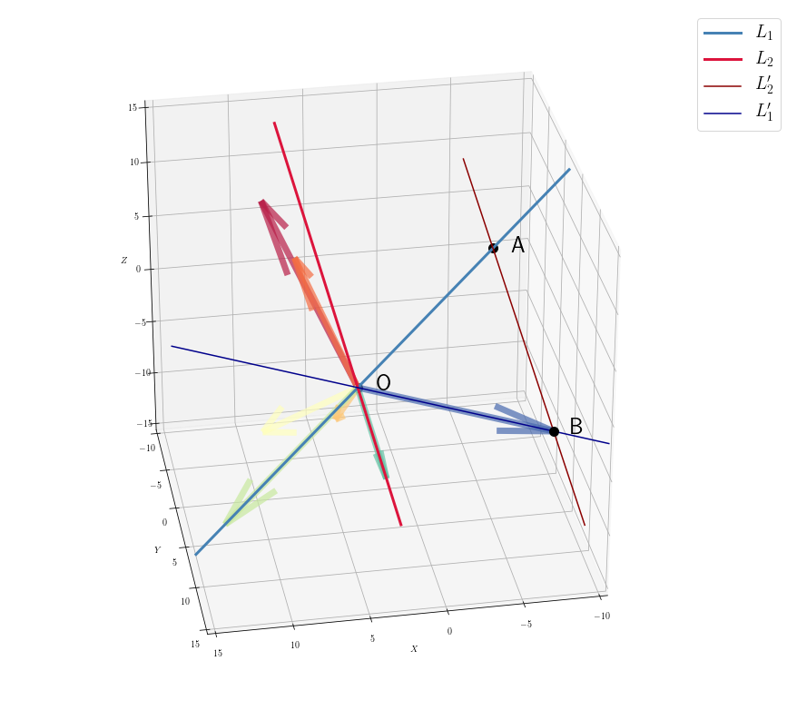

```python
f = plt.figure(figsize=(14,14)); ax = f.add_subplot(111, projection='3d')

cq = numpy.arange(0.05, 1, 0.15)
cq = numpy.concatenate((cq, numpy.repeat(cq, 2)))
cq = plt.cm.Spectral(cq)
t = 1.5

q = ax.quiver(7*[xO], 7*[yO], 7*[zO], xQ, yQ, zQ, colors=cq, lw=7, alpha=0.7)

ax.plot(X1,Y1,Z1, c='steelblue', lw=3, label=r'$L_1$')
ax.plot(X2,Y2,Z2, c='crimson', lw=3, label=r'$L_2$')
ax.plot(X3,Y3,Z3, c='darkred', label=r'$L_2^{\prime}$')
ax.plot(X4,Y4,Z4, c='darkblue', label=r'$L_1^{\prime}$')

for point in P:
    ax.scatter(int(point[0]), int(point[1]), int(point[2]), point[3], c='black', s=100)
    ax.text(int(point[0])-t, int(point[1])-t, int(point[2])-t, point[3], fontsize=25)

ax.set_xlim([-10,15]); ax.set_ylim([-10,15]); ax.set_zlim([-15,15])
ax.set_xlabel(r'$X$'); ax.set_ylabel(r'$Y$'); ax.set_zlabel(r'$Z$')
ax.view_init(30,80); ax.legend(fontsize=20,bbox_to_anchor=(1.1, 1.0));
```